# Matrix Formulation & SEM Softwares

Subhajit Chattopadhyay

11/6/2020

### Matrix Formulation - McArdle and McDonald

There are such procedures, which allow the expression of the equations of a path diagram as the product of several matrices.

Not only does such an approach allow one to turn a path diagram into a set of path equations with less risk of error, but in fact one need not explicitly write down the path equations at all—one can carry out the calculation of implied correlations directly via operations on the matrices.

Following methods are popular -

- McArdle and McDonald (1984)
- Benter-Weeks(1980)
- McArdle(1980)
- McDonald(1978)

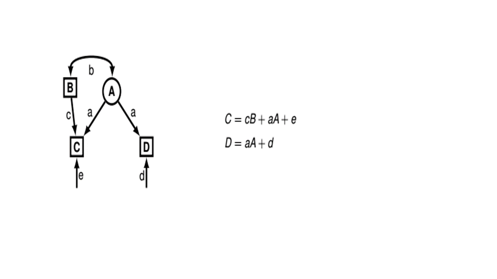

From the above diagramme following equations can be written -
$$C = c * B + a * A + e$$
$$D = a * A + d$$
Now the above equaiton can also be written in matrix form in the folloiwng manner -

$$A = 0*A + 0*B + 0*C + 0*D$$
$$B = 0*A + 0*B + 0*C + B$$
$$C = a * A + c * B + 0 * C + 0 * D + e$$
$$D = a * A + 0 * B + 0 * C + 0 * D +
d$$

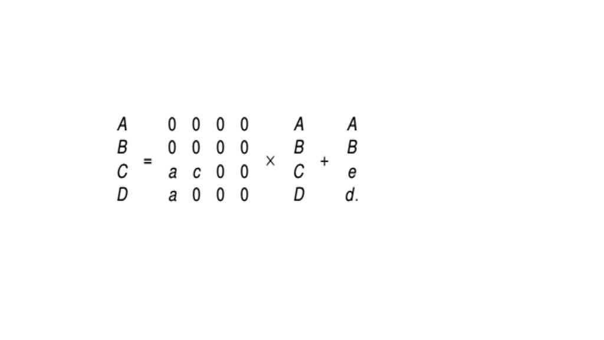

$$v = A * v + u$$

$$v * (I - A) = u$$
$$v = (I - A)^{-1} u$$
Now the covariance / correlation can be expressed as

$$\frac{vv^{\prime}}{n} = \frac{(I -
A)^{-1} u u{^\prime}(I -A)^{-1{^\prime}}}{n}$$
Now , $u * u^{\prime}$ is another covariance matrix , which can be donated as $S$ , so

$$C = \frac{v*v{^\prime}}{n} = \frac{(I -
A)^{-1} * S * (I -A)^{-1{^\prime}}}{n}$$

McArdle and McDonald (1984) defines the structure of the equation in the following manner -

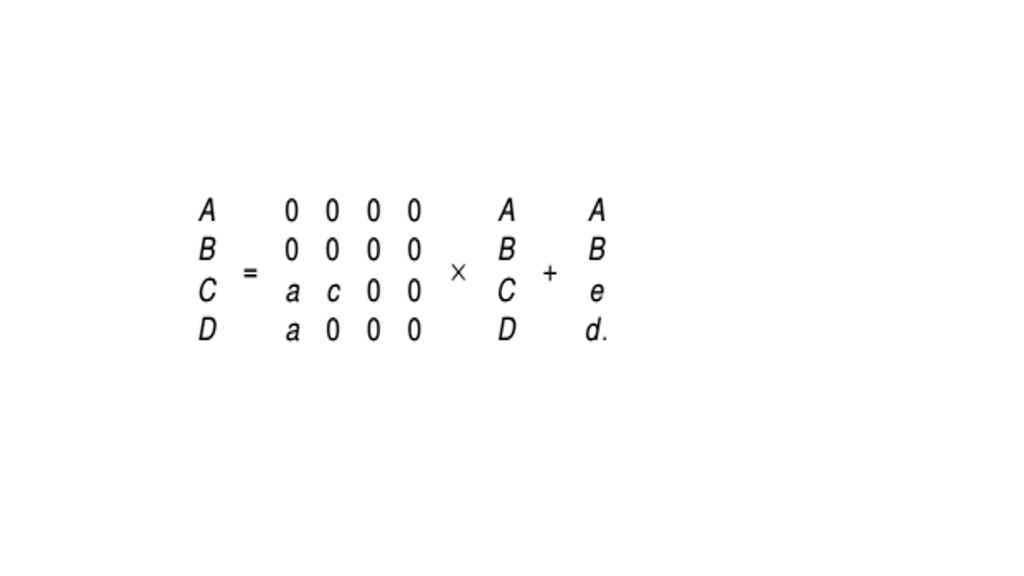

$$C = F * (I - A)^{-1} * S * (I
-A)^{-1{^\prime}} * F{^\prime}$$

where , there are “t” variables out of which “m” are measured -

$A$ is a (t * t) matrix

$S$ is a (t * t) matrix

$F$ is a (m * t) matrix

### Benter-Weeks Model

$$\eta = \beta * \eta + \gamma *
\xi$$
where, there are “q” no of DVs and “r” no of IVs are there.

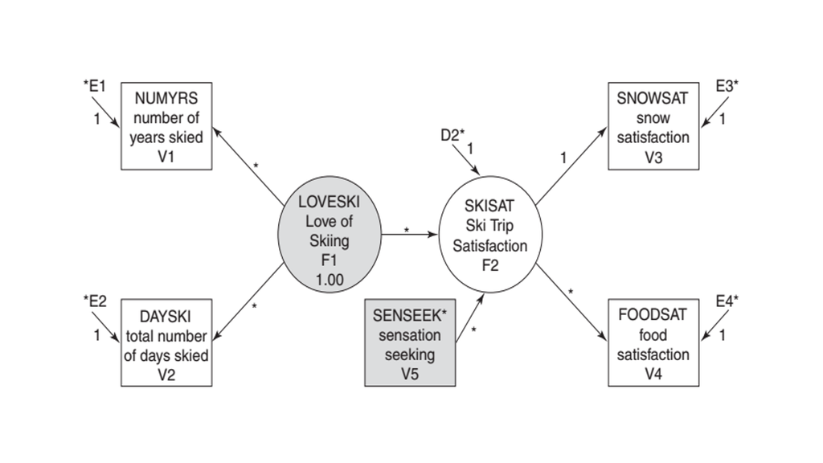

In the example, SKISAT, SNOWSAT, FOODSAT, NUMYRS, and DAYSKI are all DVs because they all have at least one line with a single-headed arrow pointing to them. Notice that SKISAT is a latent variable and also a dependent variable.

In the above model , r = 7 and q = 5

If the above above diagramme is represented in terms of the Benter-Weeks model, it would like

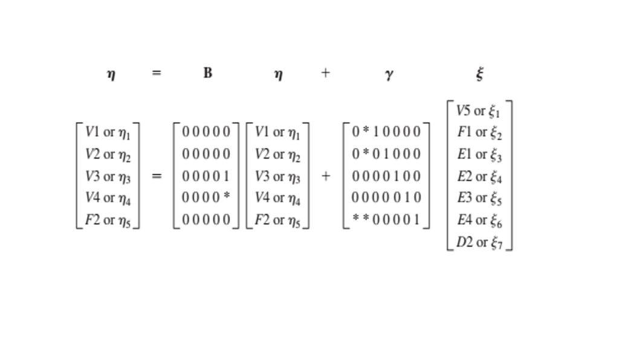

### Computer Programmes - SEM

- AMOS
- LISREL
- CALIS
- Lavaan
- sem
- Mx
- OpenMx
- Mplus
- SEPATH

### Introduction to Lavaan

- Defining the model
  - Specifying the relationship among measured variables
  - Specifying the relationship among latent variables
  - Specifying the relationship among the latent and measured variables
- Looking the model fit
- Visual representation of the model

Using Lavvan for FA - Example - 1

```r
library(lavaan)
library(semPlot)
library(psych)
library(psychTools)

test1 <- lavaan::HolzingerSwineford1939

# The data consists of mental ability test scores of e children from two different schools Pasteur and Grant-White.

str(test1)
```

```
## 'data.frame':    301 obs. of  15 variables:
##  $ id    : int  1 2 3 4 5 6 7 8 9 11 ...
##  $ sex   : int  1 2 2 1 2 2 1 2 2 2 ...
##  $ ageyr : int  13 13 13 13 12 14 12 12 13 12 ...
##  $ agemo : int  1 7 1 2 2 1 1 2 0 5 ...
##  $ school: Factor w/ 2 levels "Grant-White",..: 2 2 2 2 2 2 2 2 2 2 ...
##  $ grade : int  7 7 7 7 7 7 7 7 7 7 ...
##  $ x1    : num  3.33 5.33 4.5 5.33 4.83 ...
##  $ x2    : num  7.75 5.25 5.25 7.75 4.75 5 6 6.25 5.75 5.25 ...
##  $ x3    : num  0.375 2.125 1.875 3 0.875 ...
##  $ x4    : num  2.33 1.67 1 2.67 2.67 ...
##  $ x5    : num  5.75 3 1.75 4.5 4 3 6 4.25 5.75 5 ...
##  $ x6    : num  1.286 1.286 0.429 2.429 2.571 ...
##  $ x7    : num  3.39 3.78 3.26 3 3.7 ...
##  $ x8    : num  5.75 6.25 3.9 5.3 6.3 6.65 6.2 5.15 4.65 4.55 ...
##  $ x9    : num  6.36 7.92 4.42 4.86 5.92 ...
```

```r
View(test1)

summary(test1)
```

```
##        id             sex            ageyr        agemo
##  Min.   :  1.0   Min.   :1.000   Min.   :11   Min.   : 0.000
##  1st Qu.: 82.0   1st Qu.:1.000   1st Qu.:12   1st Qu.: 2.000
##  Median :163.0   Median :2.000   Median :13   Median : 5.000
##  Mean   :176.6   Mean   :1.515   Mean   :13   Mean   : 5.375
##  3rd Qu.:272.0   3rd Qu.:2.000   3rd Qu.:14   3rd Qu.: 8.000
##  Max.   :351.0   Max.   :2.000   Max.   :16   Max.   :11.000
##
##          school        grade             x1               x2
##  Grant-White:145   Min.   :7.000   Min.   :0.6667   Min.   :2.250
##  Pasteur    :156   1st Qu.:7.000   1st Qu.:4.1667   1st Qu.:5.250
##                    Median :7.000   Median :5.0000   Median :6.000
##                    Mean   :7.477   Mean   :4.9358   Mean   :6.088
##                    3rd Qu.:8.000   3rd Qu.:5.6667   3rd Qu.:6.750
##                    Max.   :8.000   Max.   :8.5000   Max.   :9.250
##                    NA's   :1
##        x3              x4              x5              x6
##  Min.   :0.250   Min.   :0.000   Min.   :1.000   Min.   :0.1429
##  1st Qu.:1.375   1st Qu.:2.333   1st Qu.:3.500   1st Qu.:1.4286
##  Median :2.125   Median :3.000   Median :4.500   Median :2.0000
##  Mean   :2.250   Mean   :3.061   Mean   :4.341   Mean   :2.1856
##  3rd Qu.:3.125   3rd Qu.:3.667   3rd Qu.:5.250   3rd Qu.:2.7143
##  Max.   :4.500   Max.   :6.333   Max.   :7.000   Max.   :6.1429
##
##        x7              x8               x9
##  Min.   :1.304   Min.   : 3.050   Min.   :2.778
##  1st Qu.:3.478   1st Qu.: 4.850   1st Qu.:4.750
##  Median :4.087   Median : 5.500   Median :5.417
##  Mean   :4.186   Mean   : 5.527   Mean   :5.374
##  3rd Qu.:4.913   3rd Qu.: 6.100   3rd Qu.:6.083
##  Max.   :7.435   Max.   :10.000   Max.   :9.250
##
```

```r
test2 <- test1[,-c(1,5,6)]

test.cor <- round(cor(test2),2)

test.cor
```

```
##         sex ageyr agemo    x1    x2    x3    x4    x5    x6    x7    x8   x9
## sex    1.00 -0.16  0.02 -0.08 -0.12 -0.18  0.12  0.06  0.01  0.12 -0.04 0.05
## ageyr -0.16  1.00 -0.24 -0.06 -0.02  0.04 -0.20 -0.22 -0.17  0.11  0.24 0.10
## agemo  0.02 -0.24  1.00  0.05  0.05  0.03 -0.02 -0.04  0.01  0.06  0.01 0.03
## x1    -0.08 -0.06  0.05  1.00  0.30  0.44  0.37  0.29  0.36  0.07  0.22 0.39
## x2    -0.12 -0.02  0.05  0.30  1.00  0.34  0.15  0.14  0.19 -0.08  0.09 0.21
## x3    -0.18  0.04  0.03  0.44  0.34  1.00  0.16  0.08  0.20  0.07  0.19 0.33
## x4     0.12 -0.20 -0.02  0.37  0.15  0.16  1.00  0.73  0.70  0.17  0.11 0.21
## x5     0.06 -0.22 -0.04  0.29  0.14  0.08  0.73  1.00  0.72  0.10  0.14 0.23
## x6     0.01 -0.17  0.01  0.36  0.19  0.20  0.70  0.72  1.00  0.12  0.15 0.21
## x7     0.12  0.11  0.06  0.07 -0.08  0.07  0.17  0.10  0.12  1.00  0.49 0.34
## x8    -0.04  0.24  0.01  0.22  0.09  0.19  0.11  0.14  0.15  0.49  1.00 0.45
## x9     0.05  0.10  0.03  0.39  0.21  0.33  0.21  0.23  0.21  0.34  0.45 1.00
```

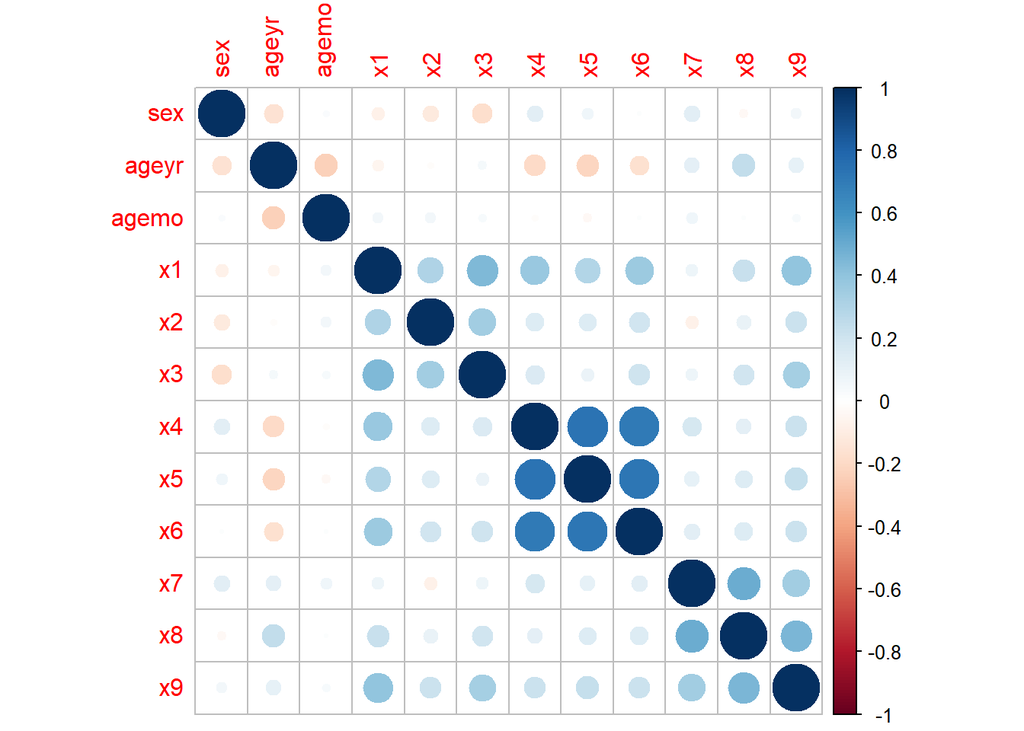

```r
library(corrplot)

corrplot(test.cor)
```

```r
test3 <- test1[,-c(1:6)] # removing all the demographic variables

test.cor1 <- round(cor(test3),2)

test.cor1
```

```
##      x1    x2   x3   x4   x5   x6    x7   x8   x9
## x1 1.00  0.30 0.44 0.37 0.29 0.36  0.07 0.22 0.39
## x2 0.30  1.00 0.34 0.15 0.14 0.19 -0.08 0.09 0.21
## x3 0.44  0.34 1.00 0.16 0.08 0.20  0.07 0.19 0.33
## x4 0.37  0.15 0.16 1.00 0.73 0.70  0.17 0.11 0.21
## x5 0.29  0.14 0.08 0.73 1.00 0.72  0.10 0.14 0.23
## x6 0.36  0.19 0.20 0.70 0.72 1.00  0.12 0.15 0.21
## x7 0.07 -0.08 0.07 0.17 0.10 0.12  1.00 0.49 0.34
## x8 0.22  0.09 0.19 0.11 0.14 0.15  0.49 1.00 0.45
## x9 0.39  0.21 0.33 0.21 0.23 0.21  0.34 0.45 1.00
```

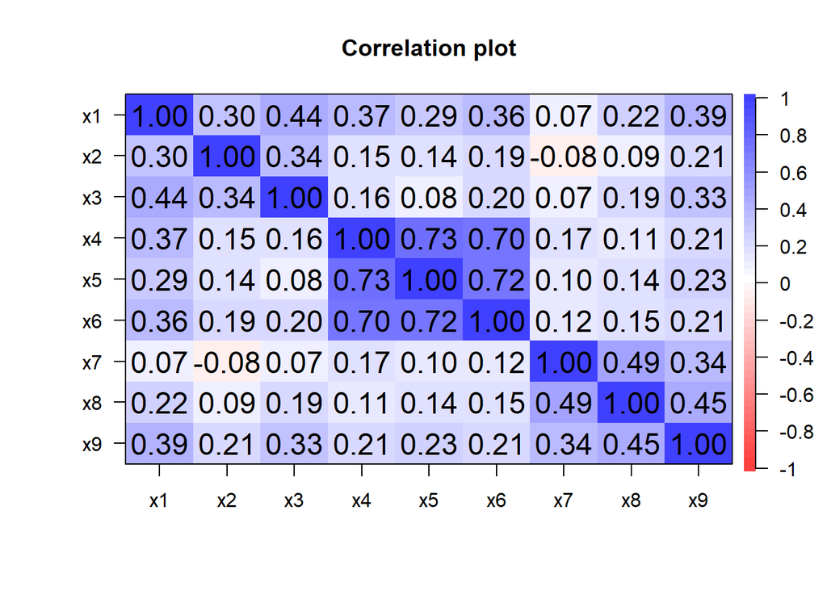

```r
cor.plot(test.cor1)
```

```r
fa1 <- factanal(~test3$x1 + test3$x2 + test3$x3 + test3$x4 + test3$x5 + test3$x4 + test3$x5 + test3$x6 , factors = 3)

fa1
```

```
##
## Call:
## factanal(x = ~test3$x1 + test3$x2 + test3$x3 + test3$x4 + test3$x5 +     test3$x4 + test3$x5 + test3$x6, factors = 3)
##
## Uniquenesses:
## test3$x1 test3$x2 test3$x3 test3$x4 test3$x5 test3$x6
##    0.572    0.776    0.458    0.005    0.126    0.357
##
## Loadings:
##          Factor1 Factor2 Factor3
## test3$x1  0.252   0.588   0.136
## test3$x2  0.104   0.462
## test3$x3          0.735
## test3$x4  0.748   0.166   0.638
## test3$x5  0.929
## test3$x6  0.743   0.250   0.167
##
##                Factor1 Factor2 Factor3
## SS loadings      2.051   1.198   0.457
## Proportion Var   0.342   0.200   0.076
## Cumulative Var   0.342   0.541   0.618
##
## The degrees of freedom for the model is 0 and the fit was 0
```

```r
# FA with Lavaan #

model1 <- 'fact1 =~ x1 + x2 + x3
           fact2 =~ x4 + x5 + x6
           fact3 =~ x7 + x8 + x9'


fit <- cfa(model = model1, data = test3)

fit
```

```
## lavaan 0.6-19 ended normally after 35 iterations
##
##   Estimator                                         ML
##   Optimization method                           NLMINB
##   Number of model parameters                        21
##
##   Number of observations                           301
##
## Model Test User Model:
##
##   Test statistic                                85.306
##   Degrees of freedom                                24
##   P-value (Chi-square)                           0.000
```

```r
summary(fit)
```

```
## lavaan 0.6-19 ended normally after 35 iterations
##
##   Estimator                                         ML
##   Optimization method                           NLMINB
##   Number of model parameters                        21
##
##   Number of observations                           301
##
## Model Test User Model:
##
##   Test statistic                                85.306
##   Degrees of freedom                                24
##   P-value (Chi-square)                           0.000
##
## Parameter Estimates:
##
##   Standard errors                             Standard
##   Information                                 Expected
##   Information saturated (h1) model          Structured
##
## Latent Variables:
##                    Estimate  Std.Err  z-value  P(>|z|)
##   fact1 =~
##     x1                1.000
##     x2                0.554    0.100    5.554    0.000
##     x3                0.729    0.109    6.685    0.000
##   fact2 =~
##     x4                1.000
##     x5                1.113    0.065   17.014    0.000
##     x6                0.926    0.055   16.703    0.000
##   fact3 =~
##     x7                1.000
##     x8                1.180    0.165    7.152    0.000
##     x9                1.082    0.151    7.155    0.000
##
## Covariances:
##                    Estimate  Std.Err  z-value  P(>|z|)
##   fact1 ~~
##     fact2             0.408    0.074    5.552    0.000
##     fact3             0.262    0.056    4.660    0.000
##   fact2 ~~
##     fact3             0.173    0.049    3.518    0.000
##
## Variances:
##                    Estimate  Std.Err  z-value  P(>|z|)
##    .x1                0.549    0.114    4.833    0.000
##    .x2                1.134    0.102   11.146    0.000
##    .x3                0.844    0.091    9.317    0.000
##    .x4                0.371    0.048    7.779    0.000
##    .x5                0.446    0.058    7.642    0.000
##    .x6                0.356    0.043    8.277    0.000
##    .x7                0.799    0.081    9.823    0.000
##    .x8                0.488    0.074    6.573    0.000
##    .x9                0.566    0.071    8.003    0.000
##     fact1             0.809    0.145    5.564    0.000
##     fact2             0.979    0.112    8.737    0.000
##     fact3             0.384    0.086    4.451    0.000
```

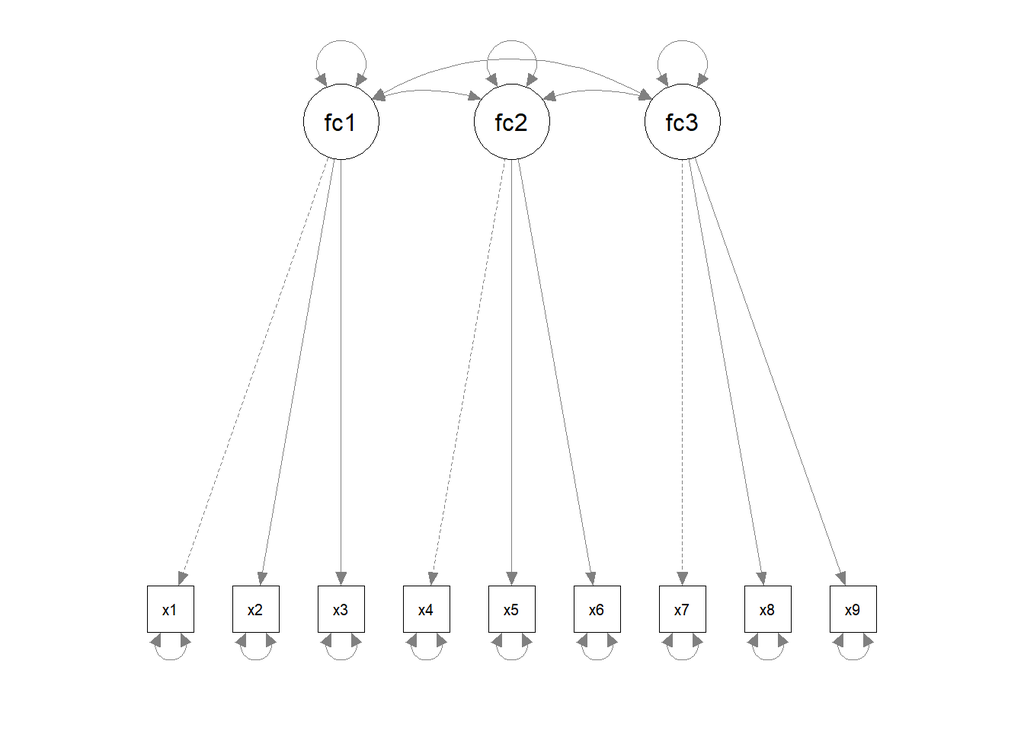

```r
semPaths(fit)
```

### SEM wih Lavaan

```r
library(lavaan)
library(semPlot)
library(psych)
library(psychTools)

test4 <- lavaan::PoliticalDemocracy

str(test4)
```

```
## 'data.frame':    75 obs. of  11 variables:
##  $ y1: num  2.5 1.25 7.5 8.9 10 7.5 7.5 7.5 2.5 10 ...
##  $ y2: num  0 0 8.8 8.8 3.33 ...
##  $ y3: num  3.33 3.33 10 10 10 ...
##  $ y4: num  0 0 9.2 9.2 6.67 ...
##  $ y5: num  1.25 6.25 8.75 8.91 7.5 ...
##  $ y6: num  0 1.1 8.09 8.13 3.33 ...
##  $ y7: num  3.73 6.67 10 10 10 ...
##  $ y8: num  3.333 0.737 8.212 4.615 6.667 ...
##  $ x1: num  4.44 5.38 5.96 6.29 5.86 ...
##  $ x2: num  3.64 5.06 6.26 7.57 6.82 ...
##  $ x3: num  2.56 3.57 5.22 6.27 4.57 ...
```

```r
# y1 - Expert ratings of the freedom of the press in 1960

# y2 - The freedom of political opposition in 1960

# y3 - The fairness of elections in 1960

# y4 - The effectiveness of the elected legislature in 1960

# y5 - Expert ratings of the freedom of the press in 1965

# y6 - The freedom of political opposition in 1965

# y7 - The fairness of elections in 1965

# y8 - The effectiveness of the elected legislature in 1965

# x1 - The gross national product (GNP) per capita in 1960

# x2 - The inanimate energy consumption per capita in 1960

# x3 - The percentage of the labor force in industry in 1960



model2 <- '

# factors

           eco60 =~ x1 + x2 + x3

           pol60 =~ y1 + y2 + y3 + y4

           pol65 =~ y5 + y6 + y7 + y8

# regressions

          pol60 ~ eco60

          pol65 ~ eco60 + pol60 '

model2
```

```
## [1] "\n\n# factors \n\n           eco60 =~ x1 + x2 + x3\n           \n           pol60 =~ y1 + y2 + y3 + y4\n           \n           pol65 =~ y5 + y6 + y7 + y8\n\n# regressions\n\n          pol60 ~ eco60 \n        \n          pol65 ~ eco60 + pol60 "
```

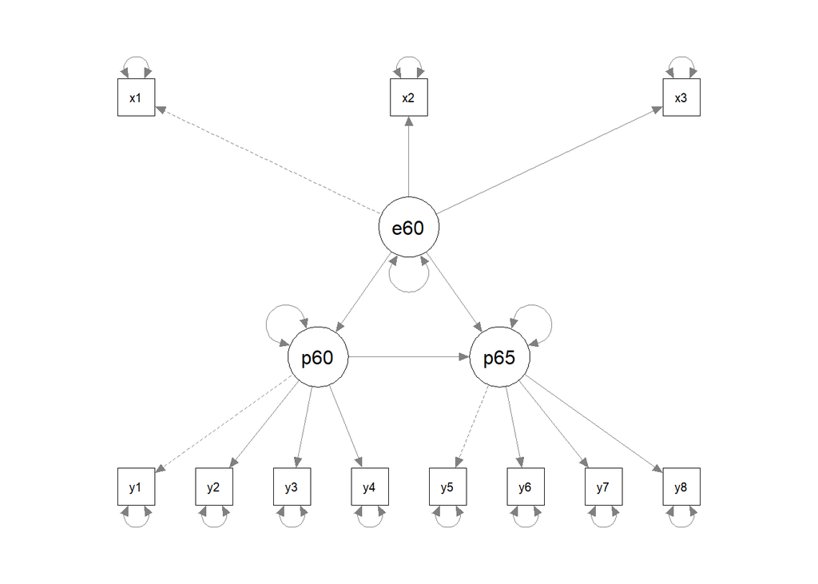

```r
fit1 <- sem(model= model2, data = test4)

semPaths(fit1)
```

```r
summary(fit1)
```

```
## lavaan 0.6-19 ended normally after 42 iterations
##
##   Estimator                                         ML
##   Optimization method                           NLMINB
##   Number of model parameters                        25
##
##   Number of observations                            75
##
## Model Test User Model:
##
##   Test statistic                                72.462
##   Degrees of freedom                                41
##   P-value (Chi-square)                           0.002
##
## Parameter Estimates:
##
##   Standard errors                             Standard
##   Information                                 Expected
##   Information saturated (h1) model          Structured
##
## Latent Variables:
##                    Estimate  Std.Err  z-value  P(>|z|)
##   eco60 =~
##     x1                1.000
##     x2                2.182    0.139   15.714    0.000
##     x3                1.819    0.152   11.956    0.000
##   pol60 =~
##     y1                1.000
##     y2                1.354    0.175    7.755    0.000
##     y3                1.044    0.150    6.961    0.000
##     y4                1.300    0.138    9.412    0.000
##   pol65 =~
##     y5                1.000
##     y6                1.258    0.164    7.651    0.000
##     y7                1.282    0.158    8.137    0.000
##     y8                1.310    0.154    8.529    0.000
##
## Regressions:
##                    Estimate  Std.Err  z-value  P(>|z|)
##   pol60 ~
##     eco60             1.474    0.392    3.763    0.000
##   pol65 ~
##     eco60             0.453    0.220    2.064    0.039
##     pol60             0.864    0.113    7.671    0.000
##
## Variances:
##                    Estimate  Std.Err  z-value  P(>|z|)
##    .x1                0.082    0.020    4.180    0.000
##    .x2                0.118    0.070    1.689    0.091
##    .x3                0.467    0.090    5.174    0.000
##    .y1                1.942    0.395    4.910    0.000
##    .y2                6.490    1.185    5.479    0.000
##    .y3                5.340    0.943    5.662    0.000
##    .y4                2.887    0.610    4.731    0.000
##    .y5                2.390    0.447    5.351    0.000
##    .y6                4.343    0.796    5.456    0.000
##    .y7                3.510    0.668    5.252    0.000
##    .y8                2.940    0.586    5.019    0.000
##     eco60             0.448    0.087    5.169    0.000
##    .pol60             3.872    0.893    4.338    0.000
##    .pol65             0.115    0.200    0.575    0.565
```

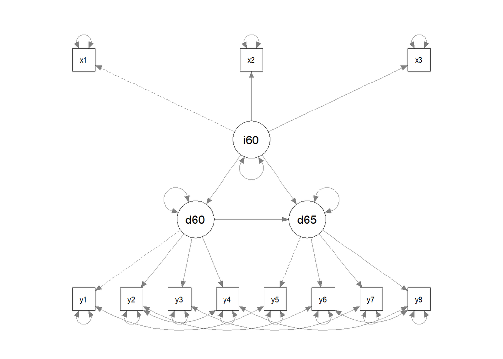

```r
model3 <- '
  # measurement model
    ind60 =~ x1 + x2 + x3
    dem60 =~ y1 + y2 + y3 + y4
    dem65 =~ y5 + y6 + y7 + y8
  # regressions
    dem60 ~ ind60
    dem65 ~ ind60 + dem60
  # residual correlations
    y1 ~~ y5
    y2 ~~ y4 + y6
    y3 ~~ y7
    y4 ~~ y8
    y6 ~~ y8'


fit2 <- sem(model = model3, data = test4)

semPaths(fit2)
```

```r
summary(fit2)
```

```
## lavaan 0.6-19 ended normally after 68 iterations
##
##   Estimator                                         ML
##   Optimization method                           NLMINB
##   Number of model parameters                        31
##
##   Number of observations                            75
##
## Model Test User Model:
##
##   Test statistic                                38.125
##   Degrees of freedom                                35
##   P-value (Chi-square)                           0.329
##
## Parameter Estimates:
##
##   Standard errors                             Standard
##   Information                                 Expected
##   Information saturated (h1) model          Structured
##
## Latent Variables:
##                    Estimate  Std.Err  z-value  P(>|z|)
##   ind60 =~
##     x1                1.000
##     x2                2.180    0.139   15.742    0.000
##     x3                1.819    0.152   11.967    0.000
##   dem60 =~
##     y1                1.000
##     y2                1.257    0.182    6.889    0.000
##     y3                1.058    0.151    6.987    0.000
##     y4                1.265    0.145    8.722    0.000
##   dem65 =~
##     y5                1.000
##     y6                1.186    0.169    7.024    0.000
##     y7                1.280    0.160    8.002    0.000
##     y8                1.266    0.158    8.007    0.000
##
## Regressions:
##                    Estimate  Std.Err  z-value  P(>|z|)
##   dem60 ~
```

[output cut: 20 more lines]

```
##                    Estimate  Std.Err  z-value  P(>|z|)
##    .x1                0.082    0.019    4.184    0.000
##    .x2                0.120    0.070    1.718    0.086
##    .x3                0.467    0.090    5.177    0.000
##    .y1                1.891    0.444    4.256    0.000
##    .y2                7.373    1.374    5.366    0.000
##    .y3                5.067    0.952    5.324    0.000
##    .y4                3.148    0.739    4.261    0.000
##    .y5                2.351    0.480    4.895    0.000
##    .y6                4.954    0.914    5.419    0.000
##    .y7                3.431    0.713    4.814    0.000
##    .y8                3.254    0.695    4.685    0.000
##     ind60             0.448    0.087    5.173    0.000
##    .dem60             3.956    0.921    4.295    0.000
##    .dem65             0.172    0.215    0.803    0.422
```